# Checks and convergence assessment for IS with INLA

9/2/2021

# Introduction

This is to test the distribution of the weights obtained with importance sampling under different scenarios. The aim is to obtain some empirical evidence about how *good* weights should be.

The aim is to estimate the mean of a bivariate normal distribution. The model is made of a bivariate normal distribution with mean $\mu_1 = (0, 0)^{\top}$ and covariance matrix

$$\Sigma_1 =
\left[
\begin{array}{cc}
1 & \rho\\
\rho & 1\\
\end{array}
\right]$$
with $\rho$ a correlation parameter.

First of all some general parameters are set to conduct the simulation study:

```r
# Set RNG seed
set.seed(1)

# Number of observed data
n.data <- 100

# Number of samples for IS
n.samples <- 100000
```

The parameters of the data generating distribution are defined below.

```r
# Likelihood
mu1 <- c(0, 0)
rho <- 0.1
Sigma1 <- matrix(c(1, rho, rho, 1), ncol = 2)
```

Next, `n.data` observations from previous multivariate normal distribution are sampled:

```r
library("mvtnorm")
# Observed data
y <- rmvnorm(n.data, mean = mu1, sigma = Sigma1)
```

The following function will compute the log-likelihood for a given value of the mean and precision (which is supposed to be known):

```r
# y: two-column matrix with observed data
# mu: vector of means
# sigma: COvariance matrix
log_lik <- function(y, mu, sigma = Sigma1) {
   return(sum(dmvnorm(y, mu, sigma, log = TRUE)))
}
```

The priors on the means (i.e., the elements of $\mu_1$) are two independent normals with zero mean and variance 1000. This function will compute the prior:

```r
# mu: Values of the mean vector
log_prior <- function(mu) {
  return(sum(dnorm(mu, mean = 0, sd = sqrt(1000))))
}
```

The sampling distribution will be a bivariate normal with different precision matrices to mimick exact, good and bad sampling distributions.

```r
# Sampling distribution
mu2 <- c(0, 0)
rho2 <- 0
Sigma2 <-matrix(c(1, rho2, rho2, 1), ncol = 2)
```

## Posterior distribution

The actual posterior distribution of $\mu_1$ is a bivariate normal, with posterior mean as follows:

$$(n\Sigma_1^{-1} + \Sigma^{-1}_0)^{-1} (\Sigma^{-1}_0 \mu_0 + \Sigma_1^{-1} \sum y)$$

```r
Sigma0 <- matrix(c(1, 0, 0, 1), ncol = 2)
```

The posterior covariance is computed first:

```r
post.covar <- solve((n.data * solve(Sigma1) + solve(Sigma0)))
post.covar
```

```
##             [,1]        [,2]
## [1,] 0.009900020 0.000980297
## [2,] 0.000980297 0.009900020
```

Then, using the posterior covariance, the posterior mean can be computed:

```r
post.mean <- post.covar %*% (solve(Sigma0) %*% matrix(c(0, 0), ncol = 1) +
  solve(Sigma1) %*% matrix(apply(y, 2, sum), ncol = 1))
post.mean
```

```
##             [,1]
## [1,] 0.070969442
## [2,] 0.002768034
```

## Importance Sampling

In this section **four scenarios** will be explored. The first one is sampling from the exact posterior. This will yield very similar weights. The second scenario considers a very wide sampling distribution, while the last scenario uses a very narrow sampling distribution. The second scenario should be able to estimate the posterior distribution, but very inefficiently (i.e., very small effective sample size). The third scenario may struggle to estimate the posterior distribution. The scond and third scenario have the bivariate normal cetered at the actual value of $mu_1 = (0. 0)^{\top}$ Finally, the fourth scenario uses a sampling distribution with a mean at $(1, 1)^{\top}$.

```r
# Samples (proposal)
#smps <- rmvnorm(n.samples, mean = mu2, sigma = Sigma2)


# Function to compute the weights
# smps: Samples, as two-column matrix
compute_weights <- function(smps) {

  # Log-Weights
  log_w <- apply(smps, 1, function(X) {
    log_aux <- log_lik(y, X) + log_prior(X) - dmvnorm(X, mean = mu2, sigma = Sigma2)
    return(log_aux)
  })

  # Summary log-weights
  #summary(log_w)

  # Re-scale weights
  ww <- exp(log_w - max(log_w))
  ww <- ww / sum(ww)

  # Summary weights
  #summary(ww)

  #Means
  est.means <- apply(smps, 2, function(X) { sum(X * ww)})
  est.means

  # Variances
  est.vars <- apply(smps, 2, function(X) { sum(X^2*ww) - sum(X * ww)^2})
  est.vars

  #Covariance
  est.cov <- sum(ww * apply(smps, 1, function(X) {
    (X[1] - est.means[1]) * (X[2] - est.means[2])
  }))
  est.cov

  # Sample size (to estimate the mean)
  n_e <- (sum(ww)^2) / sum(ww^2)

  # Sample size (to estimate the variance variance)
  n_e_sigma <- (sum(ww^2)^2)/(sum(ww^4))

  # Sample size (to estimate the kurtosis)
  # n_e_gamma
  n_e_gamma <- (sum(ww^2)^3) / (sum(ww^3)^2)

  # L2 (Elvira et al., 2018)
  L2 <- sqrt(sum((ww - 1 / length(ww))^2))

  # Function-dependent
  n_e_f <- apply(smps, 2, function(X) {
    wwtilde <- abs(X) * ww
    wwtilde <- wwtilde / sum(wwtilde)

    # ESS
    return(1 / sum(wwtilde^2))
  })

  return(list(weights = ww, mean = est.means,
    cov = matrix(c(est.vars[1], est.cov, est.cov, est.vars[2]), ncol = 2),
    n_e = n_e, n_e_sigma = n_e_sigma, n_e_gamma = n_e_gamma, L2 = L2,
    n_e_f = n_e_f))
}


# Print results
print_results <- function(res) {
  cat("\nPosterior means:\n")
  print(res$mean)
  cat("\nPosterior covariance:\n")
  print(res$cov)
  cat("\nSample size (to estimate the mean)\n")
  print(res$n_e)
  cat("\nSample size (to estimate the variance)\n")
  print(res$n_e_sigma)
  cat("\nSample size (to estimate the kurtosis)\n")
  print(res$n_e_gamma)
  cat("\nL2 discrepancy\n")
  print(res$L2)
  cat("\nSample size (per variable)\n")
  print(res$n_e_f)
}
```

### Sampling from the true posterior

```r
# Samples: true posterior
smps1 <- rmvnorm(n.samples, mean = post.mean, sigma = post.covar)
res1 <- compute_weights(smps1)
print_results(res1)
```

```
##
## Posterior means:
## [1] 0.071393178 0.003042408
##
## Posterior covariance:
##              [,1]         [,2]
## [1,] 0.0049619126 0.0004898771
## [2,] 0.0004898771 0.0049999551
##
## Sample size (to estimate the mean)
## [1] 75132.6
##
## Sample size (to estimate the variance)
## [1] 55752.84
##
## Sample size (to estimate the kurtosis)
## [1] 59445.18
##
## L2 discrepancy
## [1] 0.001819286
##
## Sample size (per variable)
## [1] 61209.17 71689.66
```

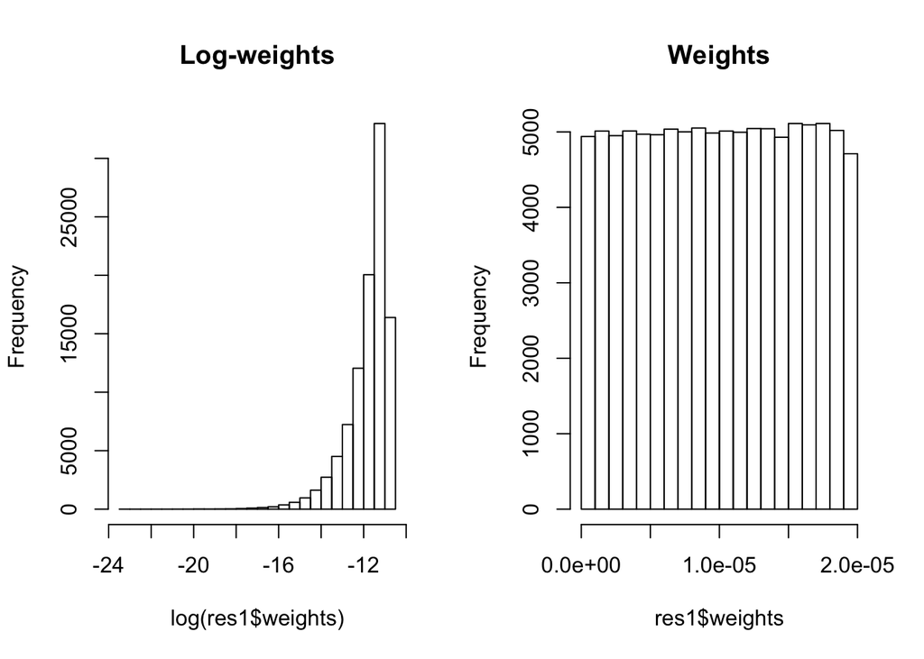

### Sampling from wide proposal

The *wide* proposal is made of using a diagonal matrix which is 10 times the diagonal of the actual posterior covariance.

```r
# Samples: wide proposal
#Sigma_wide <- matrix(c(10, 0, 0, 10), ncol = 2)
Sigma_wide <- 10 * diag(diag(post.covar), 2, 2)
smps2 <- rmvnorm(n.samples, mean = c(0, 0), sigma = Sigma_wide)
res2 <- compute_weights(smps2)
print_results(res2)
```

```
##
## Posterior means:
## [1] 0.06510933 0.00255766
##
## Posterior covariance:
##              [,1]         [,2]
## [1,] 0.0091043133 0.0007785556
## [2,] 0.0007785556 0.0091233401
##
## Sample size (to estimate the mean)
## [1] 16966.31
##
## Sample size (to estimate the variance)
## [1] 9047.843
##
## Sample size (to estimate the kurtosis)
## [1] 10109.73
##
## L2 discrepancy
## [1] 0.006995736
##
## Sample size (per variable)
## [1] 15555.69 20613.97
```

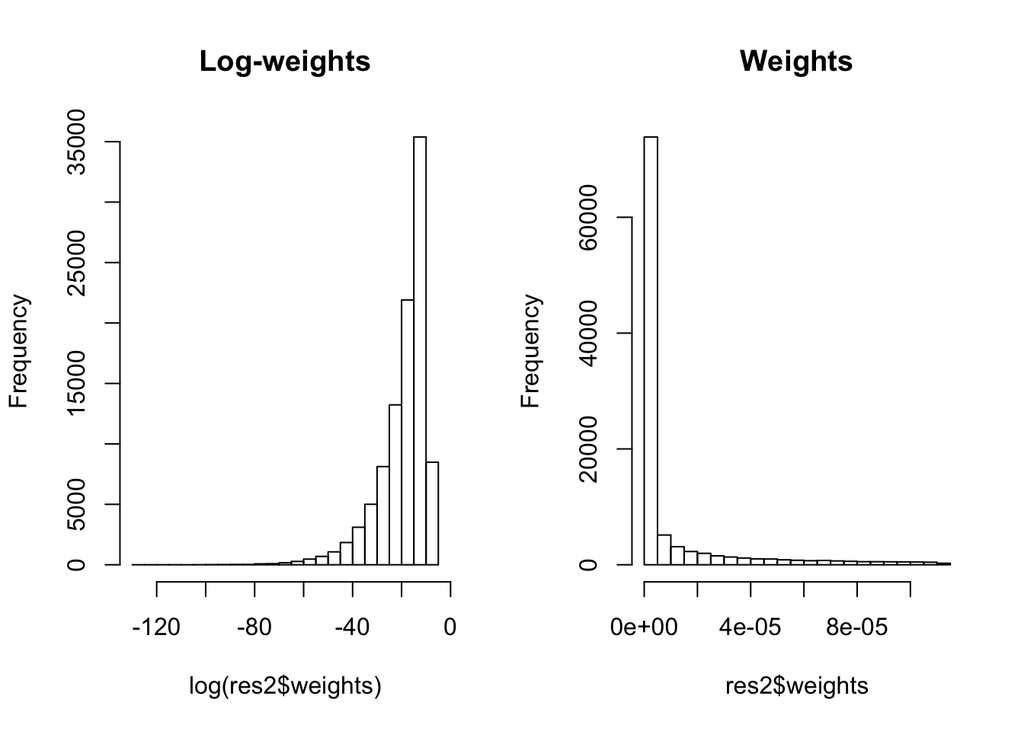

### Sampling from narrow proposal

The *narrow* proposal is made by using a diagonal covariance matrix with entries diagonal of the tru posterior covariance divided by 10.

```r
# Samples: narrow proposal
#Sigma_narrow <- matrix(c(1 / 10, 0, 0, 1 / 10), ncol = 2)
Sigma_narrow <- diag(diag(post.covar), 2, 2) / 10
smps3 <- rmvnorm(n.samples, mean = c(0, 0), sigma = Sigma_narrow)
res3 <- compute_weights(smps3)
print_results(res3)
```

```
##
## Posterior means:
## [1]  0.0065440042 -0.0003943835
##
## Posterior covariance:
##              [,1]         [,2]
## [1,] 9.017679e-04 8.739688e-06
## [2,] 8.739688e-06 9.005732e-04
##
## Sample size (to estimate the mean)
## [1] 95386.53
##
## Sample size (to estimate the variance)
## [1] 86025.75
##
## Sample size (to estimate the kurtosis)
## [1] 88597.67
##
## L2 discrepancy
## [1] 0.0006954572
##
## Sample size (per variable)
## [1] 59247.20 66186.42
```

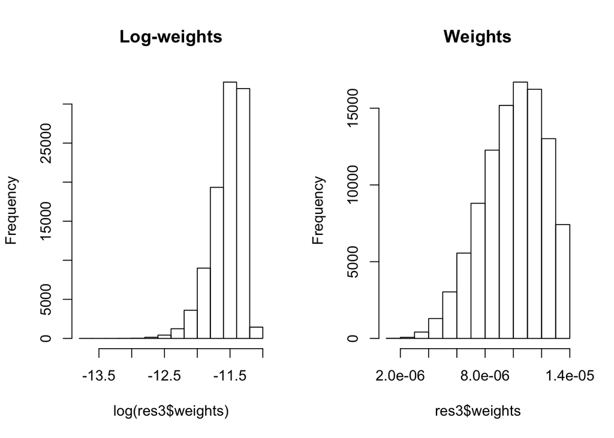

### Sampling from *shifted* proposal

The *shifted* proposal is made by using a diagonal covariance matrix with the entries of the diagonal of the actual posterior covariance and and a mean equal to $(1, 1)^{\top}$ (that *shifts* the proposal distribution).

```r
# Samples: true posterior
#Sigma_narrow <- matrix(c(1, 0, 0, 1), ncol = 2)
Sigma_narrow <- diag(diag(post.covar), 2, 2)
smps4 <- rmvnorm(n.samples, mean = c(1, 1), sigma = Sigma_narrow)
res4 <- compute_weights(smps4)
print_results(res4)
```

```
##
## Posterior means:
## [1] 0.7221019 0.7299556
##
## Posterior covariance:
##              [,1]         [,2]
## [1,]  0.002642020 -0.001909549
## [2,] -0.001909549  0.001758337
##
## Sample size (to estimate the mean)
## [1] 4.490946
##
## Sample size (to estimate the variance)
## [1] 1.479373
##
## Sample size (to estimate the kurtosis)
## [1] 1.664355
##
## L2 discrepancy
## [1] 0.4718689
##
## Sample size (per variable)
## [1] 4.520742 4.610178
```

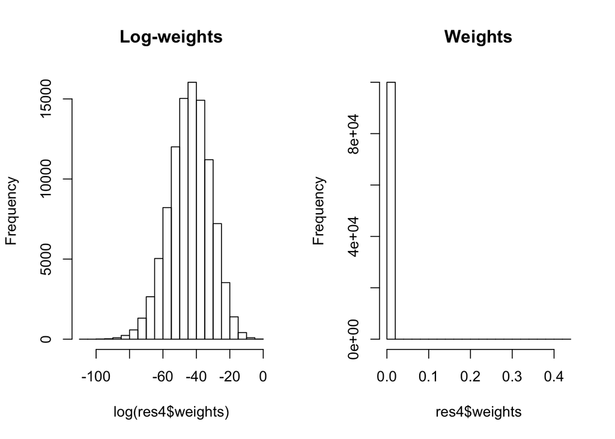

### Diagnostic plots

A diagnostic plot can be computed by estimating the empirical cumulative distribution function and comparing to the theoretical *discrete* cumulative distribution function. To compute the empirical cumulative distribution function we compute the cumulative sum of the weights *after* they ahve been reordered using the value of the associated samples. Note that this is a univariate distribution that must be computed for each sampled variable.

```r
# Diagnostic plot
# res: Results from IS
# smp: Sample (variables by column)
d_plot <- function(res, smp ) {

  # Number of variables
  n.var <- ncol(smp)
  n.samples <- nrow(smp)

  for(i in 1:n.var) {
    # Reorder weights
    idx <- order(smp[, i])
    plot(1:n.samples / n.samples, cumsum(res$weights[idx]),
      main = paste0("Variable ", i), type = "l",
      xlab = "Theoretical cumulative distribution",
      ylab = "Empirical cumulative distribution")
    abline(0, 1, lty = 2)
  }
}
```

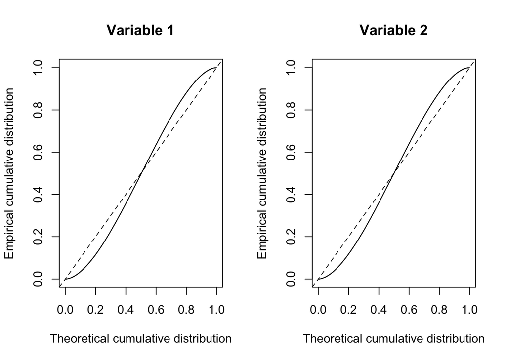

```r
par(mfrow = c(1, 2))
d_plot(res1, smps1)
```

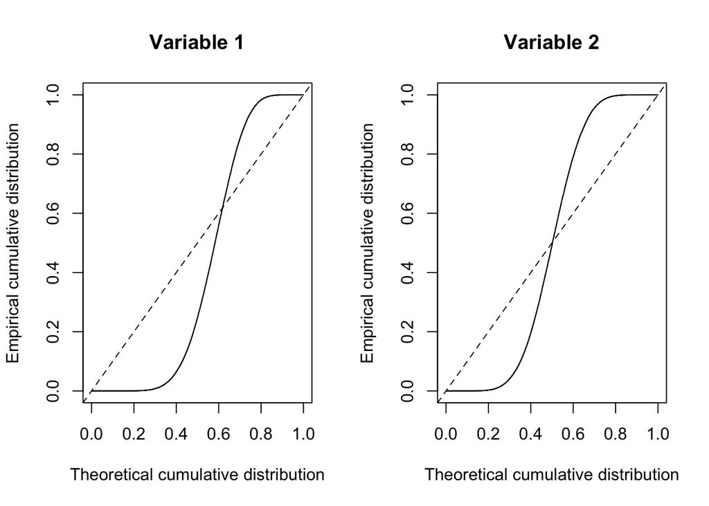

```r
par(mfrow = c(1, 2))
d_plot(res2, smps2)
```

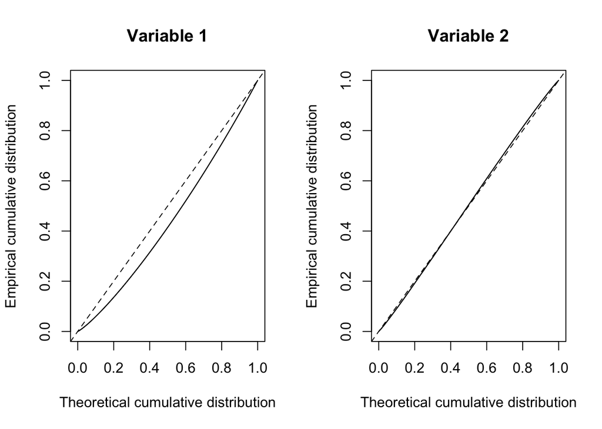

```r
par(mfrow = c(1, 2))
d_plot(res3, smps3)
```

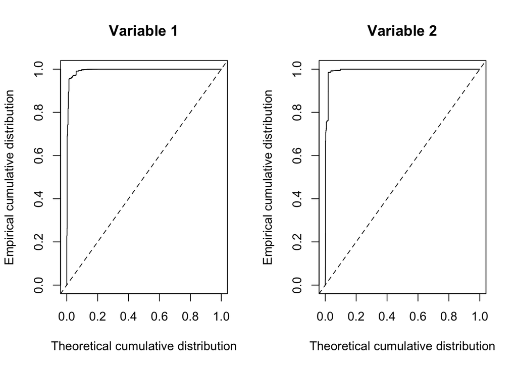

```r
par(mfrow = c(1, 2))
d_plot(res4, smps4)
```